# 36-315 Homework 07, Spring 2017

Solutions

Due Thursday, March 23rd, 2017 (11:59pm ET) on Blackboard

## Homework 07: Do The Other Lab Exam Problems

*General instructions for all assignments*:

- Use this file as the template for your submission. Delete the unnecessary text (e.g. this text, the problem statements, etc). That said, keep the nicely formatted “Problem 1”, “Problem 2”, “a.”, “b.”, etc
- Upload a single `R` Markdown file (named as: [AndrewID]-HW07.Rmd – e.g. “sventura-HW07.Rmd”) to the Homework 07 submission section on Blackboard. You do not need to upload the .html file.
- The instructor and TAs will run your .Rmd file on their computers. **If your .Rmd file does not knit on our computers, you will be automatically be deducted 10 points.**
- Your file should contain the code to answer each question in its own code block. Your code should produce plots/output that will be automatically embedded in the output (.html) file
- Each answer must be supported by written statements (unless otherwise specified)
- Include the name of anyone you collaborated with at the top of the assignment
- Include the style guide you used below under Problem 0

# Problem 0

**Style Guide and Table of Contents**

1. What style guide are you using on this assignment? (Up to 10 points will be deducted if you do not adhere to a specific style guide.)

** The solutions are written using the Hadley Wickham style guide. **

2. Remember to include a floating table of contents in your submission.
3. Use your theme for all problems.

# Instructions: Lab Exam

- For all lab exam questions, be sure to answer the question(s) asked.
- In addition to answering the questions, **write 1-3 sentences describing why you made certain choices in your graphic.** For example, why did you choose a histogram vs. density plot? Pie chart vs. rose diagram vs. bar chart vs. spine chart? Stacked vs. side-by-side bar chart? Why did you choose the bin width / number of bins in your histogram? Why did you choose the bandwidth and kernel that you picked in your density plot? Why did you decide to arrange the graphs the way you did (e.g. in a grid, horizontally, vertically). Etc.
- Remember, whenever you can supplement your answer with information from a statistical test, this is very beneficial! Feel free to run statistical tests and include this information as part of your answer.

### For all problems below, you should justify your answer with a single graph.

Using `facet_wrap()` or `facet_grid()` counts as one graph, while using `grid.arrange()` does not.

### Reminder: On the day of the lab exam, you’ll have a slightly different version of the data and problems. Additionally, there may be 1-2 short answer questions for you to answer beyond those listed here.

# Data: IMDB Movies

```r
library(tidyverse)
movies <- read_csv("https://raw.githubusercontent.com/sventura/315-code-and-datasets/master/data/imdb_test.csv")

#  Simple theme with white background, legend at the bottom
my_theme <-  theme_bw() +
  theme(axis.text = element_text(size = 12, color="indianred4"),
        text = element_text(size = 14, face="bold", color="darkslategrey"))

#  Colorblind-friendly color palette
my_colors <- c("#000000", "#56B4E9", "#E69F00", "#F0E442", "#009E73", "#0072B2",
               "#D55E00", "#CC7947")
```

# Problem 2

**Mo’ Money Mo’ Profit**

(For our purposes, a film’s profit is defined to be the `gross` minus the `budget`.)

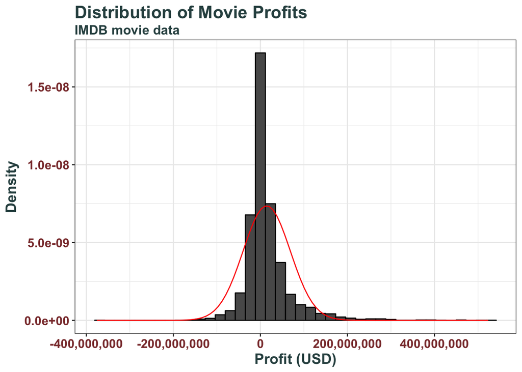

```r
movies <- mutate(movies, profit = gross - budget)

plot2 <- ggplot(data = movies) +
  geom_histogram(aes(x = profit, y = ..density..), color = "black",
                 bins = 40) +
  labs(title = "Distribution of Movie Profits",
       subtitle = "IMDB movie data",
       x = "Profit (USD)",
       y = "Density") +
  scale_x_continuous(labels = scales::comma) +
  my_theme
plot2 + stat_function(fun = dnorm, color = "red",
                      args = list(mean = mean(movies$profit, na.rm = TRUE),
                                  sd = sd(movies$profit, na.rm = TRUE)))
```

Graph: 10 points

The distribution of the profit of movies is not quite normally distributed. The density of the distribution is much larger than expected near the mean and much smaller than expected around $\pm$ 2 standard deviations from the mean than expected if the distribution were actually normal. The distribution is also slightly skewed right, and not symmetrical like the normal distribution.

```r
ks.test(movies$profit, pnorm, mean(movies$profit, na.rm = TRUE),
        sd(movies$profit, na.rm = TRUE))
```

```
    One-sample Kolmogorov-Smirnov test

data:  movies$profit
D = 0.1631, p-value < 2.2e-16
alternative hypothesis: two-sided
```

Using the Kolmogorov-Smirnov test, we test the null hypothesis that the normal distribution and the distribution of profits are the same. The test returns a p-value near 0, meaning that there is evidence to reject the null hypothesis and say that the distribution of profits is not normally distributed.

3. (5 points)

I chose to plot a histogram rather than a density plot because the density plot would show support at profit values that do not appear in the data set, where there are gaps in the distribution. I decided to use a histogram at the density scale so that I could overlay a normal distribution with the mean and standard deviation of the movie profits in the data set in order to compare the two and determine if profits were normally distributed, which I could not do at the count scale.

# Problem 3

**Lights, Camera, …**

Graph: 10 points

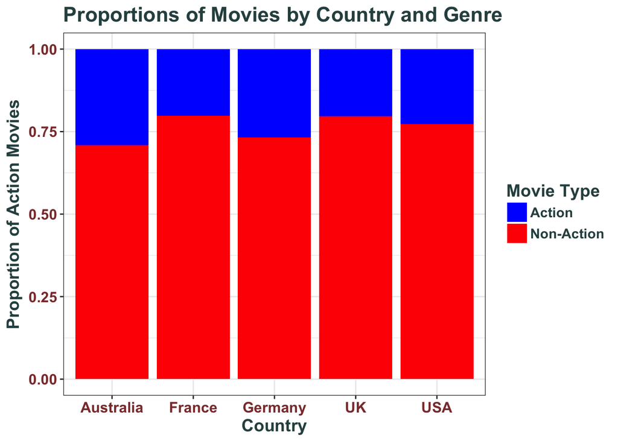

```r
action.movies <- ifelse(grepl("Action", movies$genres), "Action", "Non-Action")
movies <- mutate(movies, action = action.movies)

ggplot(movies, aes(x = country, fill = action)) +
  geom_bar(position = "fill") +
  labs(title = "Proportions of Movies by Country and Genre",
       x = "Country",
       y = "Proportion of Action Movies",
       fill = "Movie Type") +
  scale_fill_manual(values = c("blue", "red"),
                    labels = c("Action", "Non-Action")) +
  my_theme
```

```r
chisq.test(x = movies$country, y = movies$action)
```

```
##
##  Pearson's Chi-squared test
##
## data:  movies$country and movies$action
## X-squared = 4.0979, df = 4, p-value = 0.3929
```

Statistically, we can look at the results of a chi-square test to confirm this. Our chi-square test gives a p-value of 0.3929, which is not significant at any reasonable level of statistical significance. As such, we cannot conclude that there is overwhelming evidence to reject the null hypothesis of independence and conclude that the genre of movie and the country of movie are associated with each other

```r
country_action_table <- table(movies$country, movies$action)
country_action_table[,1] / (country_action_table[,1] + country_action_table[,2])
```

```
## Australia    France   Germany        UK       USA
## 0.2909091 0.2026144 0.2680412 0.2031603 0.2264706
```

Australia has the higest proportion at 0.291

I chose a stacked bar chart here because I really like the way you can clearly see changes in the proportions of attacks corresponding to each country when moving across the x-axis and looking at the individual colors.

The stacked bar chart also gives me a clear view of the marginal distribution of the proportion of Action Films, which is asked about in the problem, so it is an ideal choice in this case compared to a side-by-side bar chart.

A mosaic plot would also be a good choice here, but I think the stacked bar chart supplemented with a chi-square test is better here, since the visual trend of the changes in the proportion of Action Films for each country is so much more clear in the stacked bar chart.

# Problem 4

Graph: 10 points

*I’ve included 2 plots that display the same information to give you an example of how to use `facet_wrap`, but have an “(all)” group. It’s slightly hacky, but if you really love `facet_wrap` but want the “(all)” group, this is a hack to do it.*

[figure not shown]

```r
movies = mutate(
  movies,
  content_rating = factor(content_rating,
                          levels = c("N/A or Unrated",
                                     "Validated for All Ages (G)", "PG", "PG-13",
                                     "R","NC-17"),
                          labels = c("N/A or Unrated", "G", "PG", "PG-13" ,
                                     "R" ,"NC-17") )
)

ggplot(movies,aes(x = budget/10^8, y = imdb_score)) +
  geom_point(alpha = .1) +
  geom_smooth(method = "lm",color = "red")  +
  facet_grid(content_rating~., margin = T) +
  labs(color = "Content Rating", x = "Film / TV Budget (in 100 Million Dollars)",
       y = "Imdb Score",
       title = "IMDB Score vs. Movie Budget, \nConditional on Movie Content Rating") +
  scale_color_manual(values =colour) +
  guides(colour = guide_legend(override.aes = list(alpha = 1))) + my_theme
```

[figure not shown]

```r
movies2 = rbind(movies,movies) #duplicate the movies
movies2$content_rating = factor(movies2$content_rating,
                                levels =c( levels(movies$content_rating),
                                           "(all)")) #include a new factor level
movies2$content_rating[(nrow(movies)+1):nrow(movies2)] = "(all)"
#^ assign duplicated observations to group "(all)"

ggplot(movies2,aes(x = budget/10^8, y = imdb_score,)) +
  geom_point(alpha = .1) +
  facet_wrap(facets = ~content_rating,ncol = 2) +
  geom_smooth(method = "lm",color = "red")  +
  labs(color = "Content Rating", x = "Film / TV Budget (in 100 Million Dollars)",
       y = "Imdb Score",
       title = "IMDB Score vs. Movie Budget, Conditional on Movie Content Rating") +
  scale_color_manual(values =colour) +
  guides(colour = guide_legend(override.aes = list(alpha = 1))) + my_theme
```

```r
lin_all <- lm(imdb_score~I(budget/10^8),data= movies)
lin_ind <- lm(imdb_score~I(budget/10^8) + content_rating,data= movies)

lin_ind_int <- lm(imdb_score~I(budget/10^8)*content_rating,data= movies)

p_all <-summary(lin_all)$coef[2,4]
anova_all_plus<-anova(lin_ind,lin_ind_int)

f_test <-anova_all_plus$`Pr(>F)`[2]
```

1. (5 points)

The final plot in the graph suggests that there is a slight, but significant positive relationship between the size of a movie’s budget and their IMDB score. The confidence band, includes only positive sloping regressions, especially for movies with budgets less 200 million dollars (which is the vast majority of the films).

This positive relationship is significant, with a p-value of $1.28164 \cdot 10^{-4}$, which is much much smaller than any standard cutoff.

2. (5 points)

It is hard to tell if the relationship between `budget` and `imdb score` depends on the `content rating`. The regression lines relating `imbd score` on `budget` conditional on film `content rating` are different than the slightly positive slope for all movies, with some having almost no slope and `NC-17` having negative slopes. These trends different than the slightly positive regression have large confidence bands, which suggest the true regression could be very different.

Additionally,we can examining the strength of a linear model that allows for interactions between the `content rating` and `budget` slope, allowing each subset (based on `content rating`) to have different splots. Compared to a model that doesn’t allow each `content rating` group to have it’s own `budget` slope, we obtain a p-value of $0.051$. This is slightly over a standard threshold level of $\alpha = .05$, so we conclude that allowing each `content rating` group to have their own slopes, compared with all sharing the same slope is not statistically justified.

3. (5 points)

We decided to use a scatter plot of `budget` vs `imdb score` faceted on `content rating` adding red regression lines and confidence bands for the regression to look at linear trends. We used a scatter plot because both variables `budget` and `imdb score` are continuous and included regression lines to examine the overall relationships. 354 films with budgets listed as NA were removed.

# Problem 5

**Consider Certain Aspects**

Graph: 10 points

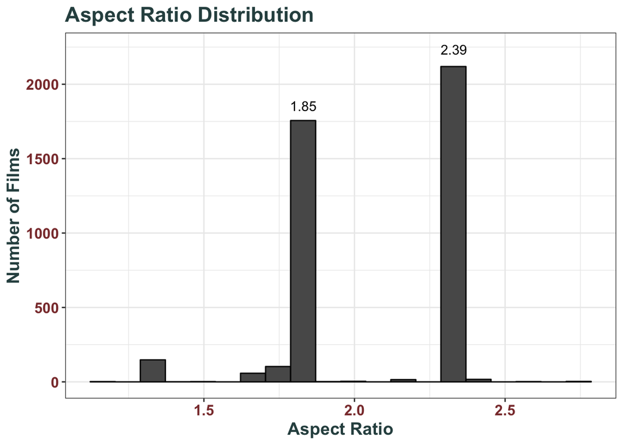

```r
aspect_ratio_new = movies$aspect_ratio
aspect_ratio_new[movies$aspect_ratio == 16] = round(16/9,2)
aspect_ratio_new[movies$aspect_ratio == 4] = round(4/3,2)
aspect_ratio_new[movies$aspect_ratio == 2.24] = 2.35 # Frozen
aspect_ratio_new[movies$aspect_ratio == 1.77] = 1.89 # Space Jam

movies_update <- mutate(movies,
                      aspect_ratio_new = aspect_ratio_new)


df_label_max <- data.frame(y = c(1756,2135),x = c(1.85,2.39))

ggplot(movies_update, aes(x = aspect_ratio_new)) +
  geom_histogram(bins = 20,color = "black") +
  geom_text(data= df_label_max,
            aes(y = y + 100, label = x, x = x-c(.02,.06))
            ) +
  labs(x = "Aspect Ratio", y = "Number of Films",
       title = "Aspect Ratio Distribution")  + my_theme
```

1. (4 points)

This question slightly depends upon the answer to **part b**, as extreme values would tend to be outliers if we saw `aspect ratio` as continuous and `aspect ratio` values that have very number of observations (say 1) could be considered an outlier if we considered `aspect ratio` continuous. The `aspect ratio`s 16 and 4 are outliers in the first sense, and both groups are all errors in recording. The first should have been 16:9 or 1.78 and the second was actually 4:3 or 1.33. The `aspect ratio`s, `1.18`, `1.2`, `1.44`, `1.77`, `1.89`, `2.24` have a single film associated with them and two of these are errrored recording, `2.24` and `1.77`.

2. (3 points)

There are two competing structure of `aspect ratios`, first any film maker can be experimental and vary the `aspect ratio` in a continuous manner, and there is the 2-4 common ratios that act like discrete structure/categorial variables as mentioned [here](http://www.red.com/learn/red-101/video-aspect-ratios). As such, it really should be viewed as I’m going to conclude that it is a continuous variable with discontinuities is the CDF, i.e. the density structure is a sum of a continuous function and point masses.

3. (3 points)

There are 2 modes of the `aspect ratio` distribution, at `1.85` and `2.39`, as we have very large numbers of observations with these exact numbers (more than 80% of the data), and the continuous structure also seems to cluster around these points, with a posssible additional model lower around `1.33`/`1.37`.

4. (5 points)

I used a histogram to capture the continuous structure of the `aspect ratio`, but also allowed the histogram to express the non-zero probablility associated with some ratios. In this plot we removed errors mentioned above included corrections of 16 to 16:9 and 4 to 4:3.

# Problem 8

(BONUS: 2 points each)

**Read Your Feedback**

Read your Lab Exam feedback on Blackboard.

1. Write 1-3 sentences about what you did well on the lab exam.
2. Write 1-3 sentences about what you did wrong on the lab exam.